# rscience-comment-removal

Dataset from: https://www.kaggle.com/areeves87/rscience-popular-comment-removal

```python
%reload_ext autoreload
%autoreload 2
%matplotlib inline
```

```python
from fastai.text import *
```

```python
#encoding = 'latin-1'
df = pd.read_csv('reddit_200k_train.csv', encoding="ISO-8859-1")
df.head()
```

|  | Unnamed: 0 | body | score.x | parent_id.x | id | created_utc.x | retrieved_on | REMOVED |
| --- | --- | --- | --- | --- | --- | --- | --- | --- |
| 0 | 1 | I've always been taught it emerged from the ea... | 2 | t3_81u15i | dv551g6 | 1520121101 | 1524782256 | False |
| 1 | 2 | As an ECE, my first feeling as "HEY THAT'S NOT... | 2 | t3_72sk35 | dnl66g6 | 1506533157 | 1507150439 | True |
| 2 | 3 | Monday: Drug companies stock dives on good new... | 5 | t3_8o88yr | e02sjhz | 1528087570 | 1532170350 | True |
| 3 | 4 | i learned that all hybrids are unfertile i won... | 0 | t3_6xg9t8 | dmfojjp | 1504290041 | 1506407514 | False |
| 4 | 5 | Well i was wanting to get wasted tonight. Not... | 3 | t3_99wi9m | e4rtew8 | 1535140675 | 1537893540 | False |

```python
valid_pct = 0.2
cut = int(valid_pct * len(df)) + 1
data_lm = (TextLMDataBunch.from_df(path=".",
                                 train_df = df[cut:],
                                 valid_df = df[:cut],
                                 text_cols = "body",
                                 label_cols = "REMOVED")
       )
```

```python
data_lm.save()
```

```python
data_lm = load_data(".")
```

```python
data_lm.show_batch()
```

```python
learn = language_model_learner(data_lm, AWD_LSTM, drop_mult=0.3)
```

```python
learn.lr_find()
```

```python
learn.recorder.plot()
```

```python
learn.fit_one_cycle(1, 1e-2, moms=(0.8,0.7))
```

```python
learn.save('fit_head')
```

```python
learn.load('fit_head');
```

```python
learn.fit_one_cycle(10, 1e-3, moms=(0.8,0.7))
```

```python
learn.save('fine_tuned')
```

```python
TEXT = "Newton's first law has nothing to do with"
N_WORDS = 40
N_SENTENCES = 2
```

```python
print("\n".join(learn.predict(TEXT, N_WORDS, temperature=0.75) for _ in range(N_SENTENCES)))
```

```python
learn.save_encoder('fine_tuned_enc')
```

```python
!jupyter nbconvert rscience-comment-removal.ipynb --to html --output nbs/2019-07-02_lm_only
```

```python
valid_pct = 0.2
cut = int(valid_pct * len(df)) + 1
data_clas = (TextClasDataBunch.from_df(path=".",
                                 train_df = df[cut:],
                                 valid_df = df[:cut],
                                 text_cols = "body",
                                 label_cols = "REMOVED")
       )
data_clas.save('data_clas.pkl')
```

```python
data_clas.save('data_clas.pkl')
```

```python
data_clas = load_data(path, 'data_clas.pkl', bs=bs)
```

```python
data_clas.show_batch(10)
```

| text | target |
| --- | --- |
| xxbos # < xxup u+0f3c > < xxup u+3064 > < xxup u+25d5 > _ < xxup u+25d5 > < xxup u+0f3d><u+3064 > xxup give xxup ban < xxup u+0f3c > < xxup u+3064 > < xxup u+25d5 > _ < xxup u+25d5 > < xxup u+0f3d><u+… | True |
| xxbos * * xxmaj this is purely informational . xxmaj this is xxup not medical advice . xxmaj this is xxup not a substitution for medical care . xxmaj do xxup not take advice from a random redditor . x… | False |
| xxbos xxmaj so for everybody interested in seeing the latest overhyped solar cell news , no this is not going to revolutionize the solar industry overnight . xxmaj but there are some interesting tidbi… | False |
| xxbos xxmaj while my name wo n't be anywhere near this report , and my time in this position has long since passed , i contributed some of the data that is covered in this report . xxmaj specifically … | False |
| xxbos xxmaj the title of the post is a copy and paste from the title , third and eight paragraphs of the linked academic press release here : \r \n \r \n > xxmaj cancer doctors want more research on m… | False |
| xxbos xxmaj have you ever seen a sign on the wall of a shop that says something like : \r \n \r \n * xxmaj good \r \n * xxmaj fast \r \n * xxmaj cheap \r \n \r \n * * xxmaj pick xxmaj two * * \r \n \r… | False |
| xxbos xxmaj the title of the post is a copy and paste from the second paragraph of the linked academic press release here : \r \n \r \n > xxmaj this age - related loss of stem cell function can be rev… | False |
| xxbos xxmaj the title of the post is a copy and paste from the title , first and fourth paragraphs < of the linked academic press release here : \r \n \r \n > xxmaj drug xxmaj companies xxmaj selling … | False |
| xxbos xxmaj journal xxmaj reference : \r \n \r \n xxmaj guo et al . \r \n \r \n xxmaj multi - functional xxmaj flexible xxmaj aqueous xxmaj sodium - xxmaj ion xxmaj batteries with xxmaj high xxmaj saf… | False |
| xxbos > xxmaj abstract \r \n \r \n > a novel strategy for controlling the spread of xxunk diseases such as dengue , xxmaj zika and chikungunya is to transform mosquito populations with virus - suppres… | False |

```python
learn = text_classifier_learner(data_clas, AWD_LSTM, drop_mult=0.5)
learn.load_encoder('fine_tuned_enc')
```

```python
learn.lr_find()
```

```
LR Finder is complete, type {learner_name}.recorder.plot() to see the graph.
```

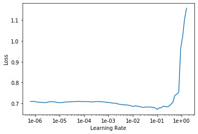

```python
learn.recorder.plot()
```

```python
learn.fit_one_cycle(5, 3e-2, moms=(0.8,0.7))
```

| epoch | train_loss | valid_loss | accuracy | time |
| --- | --- | --- | --- | --- |
| 0 | 0.630185 | 0.585736 | 0.672984 | 02:46 |
| 1 | 0.635348 | 0.575840 | 0.681520 | 02:27 |
| 2 | 0.622926 | 0.576858 | 0.678684 | 02:24 |
| 3 | 0.607235 | 0.567543 | 0.684355 | 02:35 |
| 4 | 0.603403 | 0.569452 | 0.685161 | 02:31 |

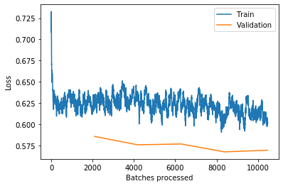

```python
learn.recorder.plot_losses()
```

```python
learn.save('first')
```

```python
learn.load('first');
```

```python
learn.freeze_to(-2)
learn.fit_one_cycle(1, slice(1e-2/(2.6**4),1e-2), moms=(0.8,0.7))
```

| epoch | train_loss | valid_loss | accuracy | time |
| --- | --- | --- | --- | --- |
| 0 | 0.585564 | 0.554534 | 0.696472 | 03:05 |

```python
learn.save('second')
```

```python
learn.load('second');
```

```python
learn.freeze_to(-3)
learn.fit_one_cycle(1, slice(5e-3/(2.6**4),5e-3), moms=(0.8,0.7))
```

| epoch | train_loss | valid_loss | accuracy | time |
| --- | --- | --- | --- | --- |
| 0 | 0.565690 | 0.536895 | 0.712052 | 04:33 |

```python
learn.save('third')
```

```python
learn.load('third');
```

```python
learn.unfreeze()
learn.fit_one_cycle(2, slice(1e-3/(2.6**4),1e-3), moms=(0.8,0.7))
```

# Let's Play

From https://www.reddit.com/r/science/wiki/rules#wiki_comment_rules

## Comment Rules

Please report any inappropriate comments to the moderators. If you feel your comment was mistakenly removed, please message the moderators and include the link to your comment.

1. No off-topic comments, memes, or jokes

Comments must be on topic and not a meme or joke. Comments should constructively contribute to the discussion or be an attempt to learn more.

1. No abusive, offensive, or spam comments

Abusive, offensive, or spam comments will be subject to removal and repeat or malicious offenders will be banned. Bots and novelty accounts are prohibited and will be banned immediately.

1. No personal anecdotes

Comments that only rely on a user's non-professional anecdotal evidence to confirm or refute a study will be removed (e.g. "I do that but that result doesn't happen to me"). Comments should be limited in personal details and scientific in nature. Including references to peer-reviewed research to support your claims is highly encouraged.

1. Comments dismissing established science must provide evidence

Comments that dispute well-established scientific concepts (e.g. gravity, vaccination, anthropogenic climate change, etc.) must be supported with appropriate peer-reviewed evidence. Links to personal blogs or 'skeptic' websites are not valid forms of evidence. Comments that are overtly fringe and/or unsubstantiated will be removed.

1. No medical advice

Offering or seeking medical advice is strictly prohibited and offending comments will be removed. Discussions regarding the advantages and/or disadvantages of certain treatments, diets, or supplements is allowed as long as relevant and reputable evidence is provided.

1. Repeat or flagrant offenders will be banned

Users that frequently or flagrantly violate the comment rules will be banned.

```python
comments = [
    "Nice try FBI.", #1 meme
    "You have no idea wtf you're talking about.", #2 abusive/offensive
    "I do that but that result doesn't happen to me", #3 personal anecdote (verbatim example)
    "No you have to flip it. If you don't believe me, just google it." #3 anecdote (something my mom would say LOL)
    "My IQ is 200. I'm pretty sure I'm right.",
    "Thank goodness my daughter wasn't vaccinated or she would be autistic too.", #4
    "Get a prescription for Benzaclin. It will clear up your acne.", #5 medical advice (though I do use benzaclin myself)
    "Sorry, my last comment was uncalled for. I was too caught up in the argument.",
    "Actually, several groups from UCLA failed to reproduce those results, and that paper ended up being retracted last year.",
    #these are copy and pasted comments.
    "I’d love to see a study looking at how many people who quit drinking also make other positive lifestyle choices leading to that feeling of how everything’s better than before.",
    "The wording of the summary implies that male moderate drinkers who quit alcohol were mentally worse off or unchanged.",
    "Pretty moderate in Europe.",
    "I’ll drink to that",
    "So we can't cure the common cold or cancer, but maybe one can cure the other?",
    "That sounds pretty cool actually",
    "Yeah, cough and post nasal drip is definitely preferable to blood in my urine, death etc...",
    "Ugh. I seriously hate post nasal drip. Keeps me up at night when I got it",
    "I have it right now and just crave a good night's rest"
]
```

```python
for comment in comments:
    pred = learn.predict(comment)
    print(comment)
    print("Moderator Removal Probability: " + str(pred[2][1].item()))
    print("\n")
```

```
Nice try FBI.
Moderator Removal Probability: 0.7242122292518616


You have no idea wtf you're talking about.
Moderator Removal Probability: 0.6369600892066956


I do that but that result doesn't happen to me
Moderator Removal Probability: 0.5380363464355469


No you have to flip it. If you don't believe me, just google it.My IQ is 200. I'm pretty sure I'm right.
Moderator Removal Probability: 0.6389226317405701


Thank goodness my daughter wasn't vaccinated or she would be autistic too.
Moderator Removal Probability: 0.6134889721870422


Get a prescription for Benzaclin. It will clear up your acne.
Moderator Removal Probability: 0.6052024960517883


Sorry, my last comment was uncalled for. I was too caught up in the argument.
Moderator Removal Probability: 0.6534530520439148


Actually, several groups from UCLA failed to reproduce those results, and that paper ended up being retracted last year.
Moderator Removal Probability: 0.3418799638748169


I’d love to see a study looking at how many people who quit drinking also make other positive lifestyle choices leading to that feeling of how everything’s better than before.
Moderator Removal Probability: 0.4386042356491089


The wording of the summary implies that male moderate drinkers who quit alcohol were mentally worse off or unchanged.
Moderator Removal Probability: 0.28610652685165405


```

[output cut: 11 more lines]

```

That sounds pretty cool actually
Moderator Removal Probability: 0.43246039748191833


Yeah, cough and post nasal drip is definitely preferable to blood in my urine, death etc...
Moderator Removal Probability: 0.4236625134944916


Ugh. I seriously hate post nasal drip. Keeps me up at night when I got it
Moderator Removal Probability: 0.7132208943367004


I have it right now and just crave a good night's rest
Moderator Removal Probability: 0.5729265809059143
```

```python
!jupyter nbconvert rscience-comment-removal.ipynb --to html --output nbs/2019-07-08_clas_0.712acc
```